# Stat420: Simulation Study 1

Author: Marko Miovski

Last Update: November 18th, 2024

# **Reproducibility**

```r
set.seed(09112001)
```

# **Simulation Study 1: Significance of Regression**

## **(1) Introduction**

### **(1.1) Significance of Regression as a Case of Testing Nested Models**

In multiple linear regression, the significance of regression test is a special case of testing **nested** models.

Testing nested models involves performing a joint hypothesis test on two models, one of which is “nested” inside the larger model (i.e., one model contains a subset of the predictors of the larger model). Testing nested models determines whether the additional predictors in the more complex model **significantly** improve the model’s ability to explain the variability in the dependent variable compared to the simpler model. If the test suggests significance, it implies the additional predictors provide important information and should be retained in the model. If the test shows the additional predictors are not significant, they can be omitted from the model.

In the case of the significance of regression test, we ask whether **any** of our predictors explain the variability in our dependent variable. That is, we ask if the response variable actually depends on any of our predictors included in the model.

### **(1.2) Models**

In this study, we explore the significance of regression test for the following known models:

**“Significant” model**:

$$Y_i = \beta_0 + \beta_1 X_{i1} + \beta_2 X_{i2} + \beta_3 X_{i3} +
\epsilon_i$$

We assume $\epsilon_i \sim N(0, \sigma^2)$, meaning our errors ($\epsilon_i$) are independent and identically distributed normal random variables with a mean of $0$ and a constant variance of $\sigma^2$. The true coefficients are $\beta_0 = 3$ and $\beta_1 = \beta_2 = \beta_3 = 1$.

**“Nonsignificant” model**:

$$Y_i = \beta_0 + \beta_1 X_{i1} + \beta_2 X_{i2} + \beta_3 X_{i3} +
\epsilon_i$$

Again, we assume $\epsilon_i \sim N(0, \sigma^2)$. The key difference here is that the true coefficients are $\beta_0 = 3$ and $\beta_1 = \beta_2 = \beta_3 = 0$, which allows us to denote the nonsignificant model as:

$$Y_i = \beta_0 + \epsilon_i$$

This model implies that $Y_i$ depends only on a constant intercept and any random noise from the error ($\epsilon_i$).

### **(1.3) Objective**

The objective of this study is to recover the empirical distributions of the following statistics for both the significant and nonsignificant models with varying levels of noise, $\epsilon_i \in (1, 5, 10)$:

- Significance of regression $\text{F-Statistic}$
- Significance of regression $\text{p-value}$
- Model $R^2$

By investigating the empirical distributions of these statistics across the significant and nonsignificant models, this study aims to compare the observed distributions to their theoretical counterparts (if these exist or are known). This study further focuses on understanding the effectiveness of regression analysis in statistical inference and interpreting how regression model characteristics, such as statistical significance, goodness of fit, and model complexity, relate to the assumption of normality and constant variance (homoscedasticity) in the error term.

## **(2) Methodology**

### **(2.1) Method**

The method used to obtain the empirical distributions of the statistics can be categorized into five parts:

1. Loading required dataset
2. Initialization for simulation
3. Nested simulation loop
4. Initialization for distribution visualization
5. Distribution visualization

Further data analysis and visualization of the summary statistics are given at the end of this section.

### **(2.2) Load “study_1.csv”**

```r
library(readr)
study_1 = read_csv("study_1.csv")
```

**(2.2.1) Explanation**

- `library(readr)` loads `readr`, a library for reading .csv files
- `study_1 = read_csv("study_1.csv")` defines a tibble containing a blank placeholder for our `y` values and the predictors `x1`, `x2`, `x3` from the dataset “study_1.csv”

### **(2.3) Initialization for Simulation**

```r
# number of observations
n = 25

# number of simulations
n_sim = 2000

# list of two model types with corresponding beta values
model_list = list(Significant = c(1, 1, 1), Nonsignificant = c(0, 0, 0))

# true standard errors
sigmas = c(1, 5, 10)

# initialize predictors
x1 = study_1$x1
x2 = study_1$x2
x3 = study_1$x3

# initialize results dataframe
results_df = data.frame(model = character(),
             std_err = numeric(),
             f_stat = numeric(),
             p_val = numeric(),
             r_sqr = numeric(),
             stringsAsFactors = FALSE)
```

**(2.3.1) Explanation**

- `n = 25` defines the number of observations for each simulation
- `n_sim = 2000` defines the number of simulations
- `model_list = list(Significant = c(1, 1, 1), Nonsignificant = c(0, 0, 0))` is a list containing the known beta parameter values for the significant and nonsignificant models
- `sigmas = c(1, 5, 10)` is a vector containing the known standard errors
- `x1 = study_1$x1` initializes the `x1` predictor variable from the `study_1` dataset, the same applies to `x2` and `x3`
- `results_df` is an empty dataframe that will store the type of model (significant or nonsignificant), the standard error value, and the necessary statistics of the model for each iteration of the simulation.

### **(2.4) Nested Simulation Loop**

**(2.4.1) Objective**

This nested loop conducts simulations to obtain the $\text{F-Statistic}$ and its $\text{p-value}$ from the significance of regression test for both the significant and nonsignificant models while also obtaining the $R^2$ of each of the models.

**(2.4.2) Iterations**

In total, the nested loop completes $12,000$ iterations. The end result will be a dataframe storing the $2000$ corresponding statistics for all of the possible combinations of the models and standard errors. The possible model and standard errors combinations are:

- Significant model with standard error of $1$
- Significant model with standard error of $5$
- Significant model with standard error of $10$
- Nonsignificant model with standard error of $1$
- Nonsignificant model with standard error of $5$
- Nonsignificant model with standard error of $10$

```r
# nested simulation loop
for (model in names(model_list)) {

  beta = model_list[[model]] # obtain beta values for current model

  for (sigma in sigmas) {    # iterate over each standard error

    for (i in 1:n_sim) {     # simulate for 2000 iterations

      # generate random noise
      eps = rnorm(n = n, mean = 0, sd = sigma)

      # generate y using model with specified beta values
      y = 3 + beta[1] * x1 + beta[2] * x2 + beta[3] * x3 + eps

      # current simulation dataframe
      sim_df = data.frame(y = y, x1 = x1, x2 = x2, x3 = x3)

      # fit linear model
      lr = lm(y ~ x1 + x2 + x3, data = sim_df)

      # for neatness.
      s = summary(lr)

      # obtain statistics
      f = s$fstatistic[1]
      p = pf(s$fstatistic[1], s$fstatistic[2], s$fstatistic[3], lower.tail = FALSE)
      r2 = s$r.squared

      # statistics dataframe
      statistics_df = data.frame(model = model,
                   std_err = sigma,
                   f_stat = f,
                   p_val = p,
                   r_sqr = r2)

      # append to results dataframe
      results_df = rbind(results_df, statistics_df)

    }
  }
}

# clean results_df row index
rownames(results_df) = 1:nrow(results_df)
```

**(2.4.3) Explanation**

**Step 1**: Model Selection

- The first loop involves iterating over each model type and obtaining its corresponding beta parameters
- `for (model in names(model_list))` selects one of the significant or nonsignificant models
- `beta = model_list[[model]]` obtains the beta parameters of the selected model

**Step 2**: Standard Error Selection

- The second loop iterates over the varying levels of the standard error for the model selected in the previous loop
- `for (sigma in sigmas)` selects one of the standard errors for the current model

**Step 3**: Simulation Iteration

- `for (i in 1:n_sim)` is the third loop and it runs a series of simulations for each combination of model type and standard error, generating data and fitting a linear regression model $2000$ times
- `eps = rnorm(n = n, mean = 0, sd = sigma)` generates the random noise with a sample size of `n`, mean of $0$, and the selected standard error from a normal distribution for the current model
- `y = 3 + beta[1] * x1 + beta[2] * x2 + beta[3] * x3 + eps` generates the $Y_i$ values for the selected model using the beta parameters, the `x1`, `x2`, `x3` predictors, and the error term for the current iteration
- `sim_df = data.frame(y = y, x1 = x1, x2 = x2, x3 = x3)` stores the generated `y` and `x1`, `x2`, `x3` values in a temporary dataframe for the current model and standard error combination
- `lr = lm(y ~ x1 + x2 + x3, data = sim_df)` fits the linear model using `sim_df` as the data for the current model and standard error type
- `f`, `p`, and `r2` are extracted from the linear model’s summary statistics
- `statistics_df` stores `f`, `p`, and `r2` for the model and standard error combination

**Step 4**: Binding to Main Results Dataframe

- `results_df = rbind(results_df, statistics_df)` appends the current iterations result’s from `statistics_df` to the main dataframe, `results_df`, which will be used to compile the simulation outcomes for this analysis
- At this stage, the nested loop repeats and begins again by selecting another combination of models and standard errors until it has looped for all of the possible combinations

**(2.4.4) Main Results Dataframe**

```r
# quick look at the resulting dataframe
head(results_df)
```

```
##         model std_err   f_stat        p_val     r_sqr
## 1 Significant       1 37.88032 1.179385e-08 0.8440296
## 2 Significant       1 33.42900 3.499106e-08 0.8268570
## 3 Significant       1 30.81829 7.006937e-08 0.8149044
## 4 Significant       1 41.32892 5.452909e-09 0.8551592
## 5 Significant       1 43.36503 3.546355e-09 0.8610147
## 6 Significant       1 68.98280 4.841957e-11 0.9078739
```

The resulting dataframe contains the model type, standard error, $\text{F-Statistic}$, $\text{p-value}$, and $R^2$ for all possible combinations of the model types and standard errors.

### **(2.5) Initialization for Distribution Visualization**

```r
# degrees of freedom for f_stat
df_1 = 3 # because 3 predictors
df_2 = 21 # because 4 parameters

# bins for histogram
bins = 50
```

**(2.5.1) Explanation**

- `df_1` pertains to the $\text{df}_1$ of the $\text{F-Statistic}$, it has a value of $3$ because there are $3$ $X$ predictors in each model
- `df_2` pertains to the $\text{df}_2$ of the $\text{F-Statistic}$, it has a value of $21$ because $\text{df}_2 = n - \text{df}_1 - 1 = 25 - 3 - 1 = 21$

### **(2.6) Distribution Visualization**

**(2.6.1) Objective**

The objective of this visualization is to compare the empirical distributions of the statistics to their theoretical counterparts (if these exist and are known). This is achieved by creating histograms along with density overlays for the statistics, for each combination of model type and standard error. To ensure apt comparison, we plot each statistic for each corresponding model type and standard error separately. The following contains a detailed explanation of how each plot set is generated. Because of the repetitive nature of generating the plots for each individual statistic, we will walk through just the first set of plots. The remainder of the plot code is hidden using `echo=FALSE` in the markdown `r` chunk.

```r
## f-stat for significant model

par(mfrow = c(3, 1)) # plots in matrix of three rows and one col

par(mar = c(5, 5, 5, 1)) # plot bounds

# subsetting for significant model with standard error of 1
sub_df = results_df[results_df$model == "Significant" & results_df$std_err == 1, ]
data = sub_df$f_stat # assigning statistic

# plot
hist(data,
    main = "Distribution: F-Statistic for the Significant Model with SE = 1",
    xlab = "Estimated F-Statistic Values",
    ylab = "Density",
    col = "lightblue",
    border = "orange",
    breaks = bins,
    prob = TRUE,
    freq = FALSE)

# theoretical density curve
curve(df(x, df1 = df_1, df2 = df_2), add = TRUE, col = "darkred", lwd = 2)

grid() # grid-line

# subsetting for significant model with standard error of 5
sub_df = results_df[results_df$model == "Significant" & results_df$std_err == 5, ]
data = sub_df$f_stat # assigning statistic

# plot
hist(data,
    main = "Distribution: F-Statistic for the Significant Model with SE = 5",
    xlab = "Estimated F-Statistic Values",
    ylab = "Density",
    col = "lightblue",
    border = "orange",
    breaks = bins,
    prob = TRUE,
    freq = FALSE)

# theoretical density curve
curve(df(x, df1 = df_1, df2 = df_2), add = TRUE, col = "darkred", lwd = 2)

grid() # grid-line

# subsetting for significant model with standard error of 10
sub_df = results_df[results_df$model == "Significant" & results_df$std_err == 10, ]
data = sub_df$f_stat  # assigning statistic

# plot
hist(data,
    main = "Distribution: F-Statistic for the Significant Model with SE = 10",
    xlab = "Estimated F-Statistic Values",
    ylab = "Density",
    col = "lightblue",
    border = "orange",
    breaks = bins,
    prob = TRUE,
    freq = FALSE)

# theoretical density curve
curve(df(x, df1 = df_1, df2 = df_2), add = TRUE, col = "darkred", lwd = 2)

grid() # grid-line
```

**(2.6.2) Explanation**

**Step 1**: Plot Sizing

- `par(mfrow = c(3, 1))` arranges the plot set in a three by one matrix
- `par(mar = c(5, 5, 5, 1))` sets the plot bounds

**Step 2**: Obtaining the Statistic

- `sub_df` is a dataframe that subsets for the specific model and standard error combination
- `data` obtains the corresponding statistic for the specific model and standard error combination

**Step 3**: Plotting

- `hist()` plots the statistic, the arguments `prob = TRUE` and `freq = FALSE` enable density overlay
- `curve(df(x, df1 = df_1, df2 = df_2), add = TRUE, col = "darkred", lwd = 2)` overlays the theoretical density curve on the distribution
- `grid()` adds some neat grid-lines

**Step 4**: Repetition

- The same is repeated for the nonsignificant model and for the $\text{p-value}$ and $R^2$ of both model types until each set of plots for all of the statistics have been generated with the only difference in the plots being that the `prob=TRUE` and `freq = FALSE` arguments not being used because the theoretical distribution for the $\text{p-value}$ is just a uniform distribution on the interval $[0, 1]$ and there is no universally “known” distribution for $R^2$ because it depends on the fit of the model

### **(2.7) Summary Statistics**

**(2.7.1) Objective**

The objective of the following nested is to generate summary statistics for the $\text{F-Statistic}$, $\text{p-value}$, and $R^2$ for the possible model type and standard error combinations.

```r
# models and standard errors
models = unique(results_df$model)
std_errors = unique(results_df$std_err)

# dataframe to store summary statistics
summary_df = data.frame(model = character(),
             std_err =  numeric(),
             f_stat_mean = numeric(),
             f_stat_sd = numeric(),
             p_val_mean = numeric(),
             p_val_sd = numeric(),
             r_sqr_mean = numeric(),
             r_sqr_sd = numeric(),
             stringsAsFactors = FALSE)

for (m in models) {         # select a model type

  for (se in std_errors) {  # select a standard error

    loop_df = results_df[results_df$model == m & results_df$std_err == se, ] # subset

    # summary statistics
    f_mean = mean(loop_df$f_stat)
    f_sd = sd(loop_df$f_stat)
    p_mean = mean(loop_df$p_val)
    p_sd = sd(loop_df$p_val)
    r2_mean = mean(loop_df$r_sqr)
    r2_sd = sd(loop_df$r_sqr)

    # temporary dataframe for current iteration
    temp_df = data.frame(model = m,
              std_err = se,
              f_stat_mean = f_mean,
              f_stat_sd = f_sd,
              p_val_mean = p_mean,
              p_val_sd = p_sd,
              r_sqr_mean = r2_mean,
              r_sqr_sd = r2_sd)

    # append to summary dataframe
    summary_df = rbind(summary_df, temp_df)

  }
}

# clean summary dataframe
colnames(summary_df) = c("Model Type",
                         "Standard Error",
                         "F-Statistic Mean",
                         "F-Statistic Standard Deviation",
                         "P-Value Mean",
                         "P-Value Standard Deviation",
                         "R-Square Mean",
                         "R-Square Standard Deviation")

summary_df = round(summary_df[, 2: 8], 4)

# table
library(knitr)
kable(summary_df, caption =
      "Simulation Summary Statistics",
      booktabs = TRUE)
```

**(2.7.2) Explanation**

**Step 1**: Initialization

- `models` holds the model type, “Significant” and “Nonsignificant
- `std_errors` holds the standard error values
- `summary_df` is an empty dataframe that will store the model type, standard error value and the summary statistics for the estimated values

**Step 2**: Loop

- `for (m in models)` selects a model
- `for (se in std_errors)` selects a standard error
- `loop_df` subsets `results_df` based on the provided model type and standard error
- Summary statistics are generated using `mean()` and `sd()`
- The summary statistics are stored in `temp_df`, a temporary dataframe storing the values obtained from the current iteration
- `temp_df` is stored in `summary_df`, the main summary statistics dataframe
- The loop repeats until all of the model types and standard errors have been iterated through

**Step 3**: Cleaning

- `colnames(summary_df)` renames the columns of the dataframe
- `round(summary_df[, 2: 8], 4)` rounds the values to four decimals

**Step 4**: Table

- `library(knitr)` imports knitr, a library useful for .pdf tables
- `kable()` is used to generate the table

### **(2.8) P-Value Proportions**

**(2.8.1) Objective**

```r
# models and standard errors
models = unique(results_df$model)
std_errors = unique(results_df$std_err)

# dataframe to store proportion statistics
proportion_df = data.frame(model = character(),
                std_err =  numeric(),
                p_val_001 = numeric(),
                p_val_005 = numeric(),
                p_val_010 = numeric(),
                stringsAsFactors = FALSE)

for (m in models) {         # select a model type

  for (se in std_errors) {  # select a standard error

    loop_df = results_df[results_df$model == m & results_df$std_err == se, ] # subset

    # obtain proportion of p_val < alpha
    p1 = mean(loop_df$p_val < 0.01)
    p2 = mean(loop_df$p_val < 0.05)
    p3 = mean(loop_df$p_val < 0.10)

    # store in current iteration dataframe
    temp_df = data.frame(model = m,
              std_err =  se,
              p_val_001 = p1,
              p_val_005 = p2,
              p_val_010 = p3,
              stringsAsFactors = FALSE)

    # bind to proportion dataframe
    proportion_df = rbind(proportion_df, temp_df)

  }
}

# cleaning
colnames(proportion_df) = c("Model Type",
                            "Standard Error",
                            "Proportion of P-Values < 0.01",
                            "Proportion of P-Values < 0.05",
                            "Proportion of P-Values < 0.10")

# table
library(knitr)
kable(proportion_df, caption =
      "P-Values less than Standard Significance Levels",
      booktabs = TRUE)
```

**(2.8.2) Explanation**

**Step 1**: Initialization

- `models` holds the model type, “Significant” and “Nonsignificant
- `std_errors` holds the standard error values
- `proportion_df` is an empty dataframe that will store the model type, standard error value and the corresponding $\text{p-value}$ proportions for the different significance levels

**Step 2**: Loop

- `for (m in models)` and `for (se in std_errors)` select the respective model type and standard error value
- `loop_df` subsets `results_df` to obtain the data for the specific model type and standard error combination
- `p1`, `p2`, and `p3` store the proportions
- The values are stored in `temp_df`, a temporary dataframe for storing the values obtained from the current iteration
- `temp_df` is stored inside `proportion_df`, the main proportion dataframe

**Step 3**: Cleaning

- `colnames(proportion_df)` renames the columns of the dataframe

**Step 4**: Table

- `library(knitr)` imports knitr
- `kable()` is used to generate the table

## **(3) Results**

### **(3.1) F-Statistic for Significant Model**

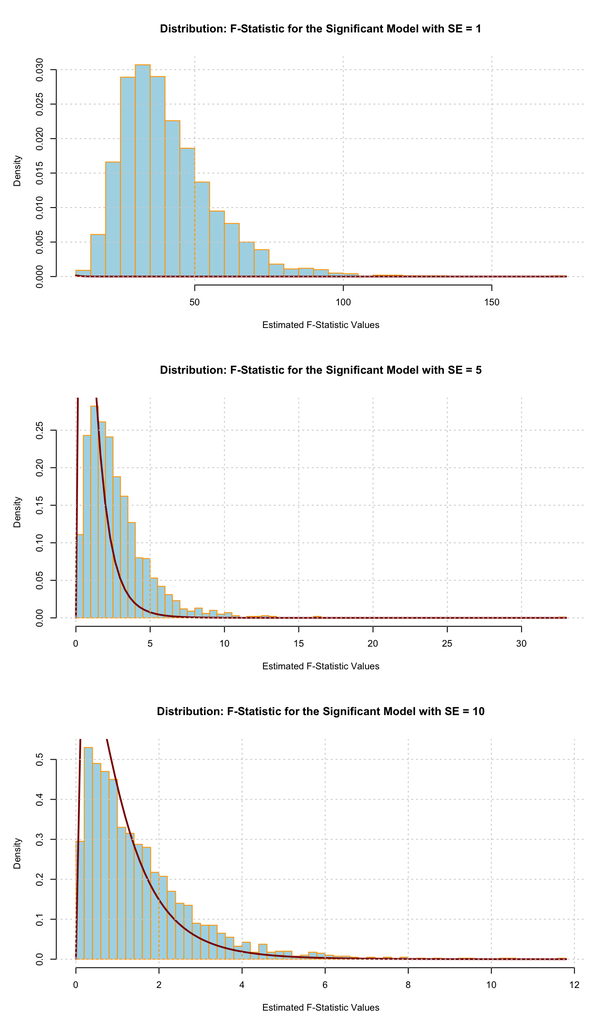

### **(3.2) F-Statistic for Nonsignificant Model**

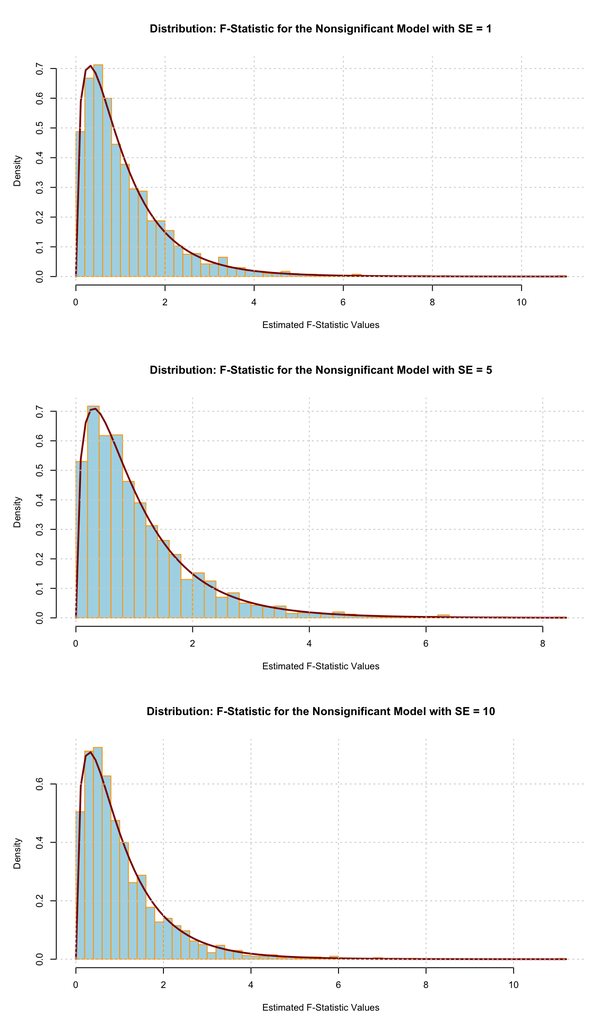

### **(3.3) P-Value for Significant Model**

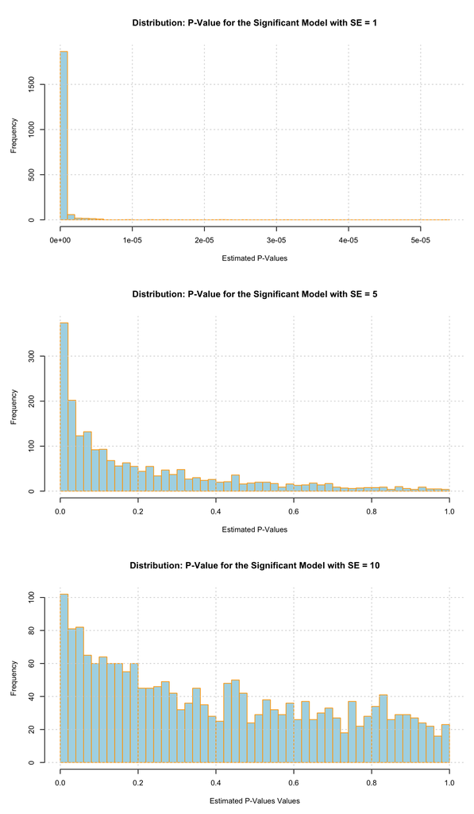

### **(3.4) P-Value for Nonsignificant Model**

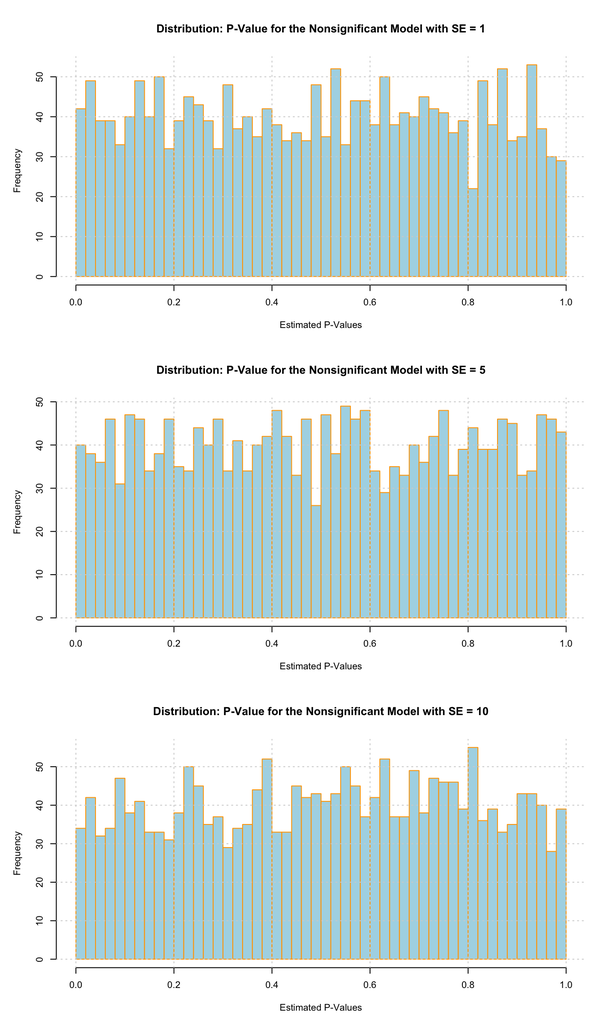

### **(3.5) R-Squared for Significant Model**

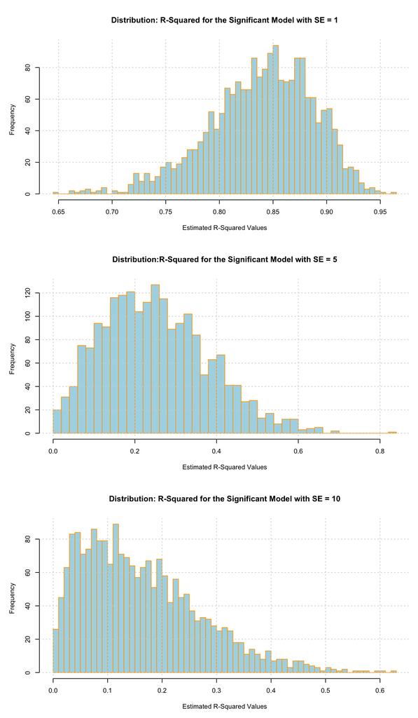

### **(3.6) R-Squared for Nonsignificant Model**

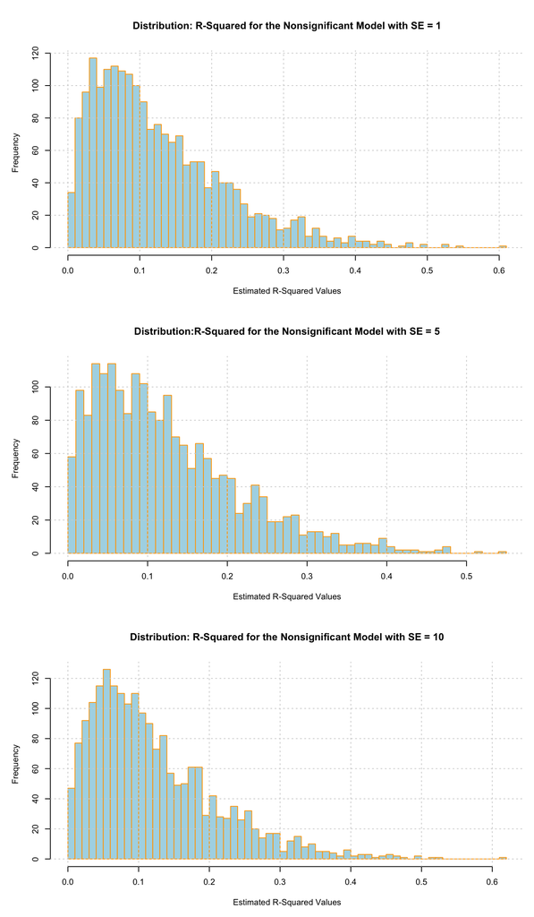

### **(3.7) Summary Statistics and P-Value Proportions**

Simulation Summary Statistics

[output not shown]

P-Values less than Standard Significance Levels

| Model Type | Standard Error | Proportion of P-Values < 0.01 | Proportion of P-Values < 0.05 | Proportion of P-Values < 0.10 |
| --- | --- | --- | --- | --- |
| Significant | 1 | 1.0000 | 1.0000 | 1.0000 |
| Significant | 5 | 0.1235 | 0.3305 | 0.4615 |
| Significant | 10 | 0.0295 | 0.1110 | 0.1950 |
| Nonsignificant | 1 | 0.0110 | 0.0565 | 0.1010 |
| Nonsignificant | 5 | 0.0080 | 0.0490 | 0.0955 |
| Nonsignificant | 10 | 0.0100 | 0.0455 | 0.0945 |

## **(4) Discussion**

### **(4.1) Theory Pertaining to the Simulation**

**(4.1.1) General Significance of Regression Test and Normality Assumption**

In the general significance of regression test, we have the following hypothesis:

$$H_0: \beta_1 = \beta_2 = \ldots = \beta_k = 0 \text{ vs. } H_1: \text{At
least one } \beta_i \neq 0, \quad \text{for } i = 1, 2, \ldots, k$$

For any specific significance level ($\alpha$), we have the following implications:

- If the $\text{p-value} < \alpha$, we reject the null and conclude that there is evidence to suggest that our regression is significant (i.e., one of the predictor variables included in the model helps explain the linear relationship with the response)
- If the $\text{p-value} > \alpha$, we fail to reject the null and conclude that there is **not** sufficient evidence to suggest that our regression is significant (i.e., one of the predictor variables included in the model does not help explain the linear relationship with the response)

In either case, what we are testing is to see whether our response variable $Y$ actually linearly depends on the predictors $X$ or not. This helps us to determine whether to include or exclude certain predictors from the model.

Now, to actually formulate this hypothesis, we need the normality assumption of the error term. Specifically, we need the assumption of constant variance for the error term. This is because constant variance of the error term, also known as homoscedasticity, ensures the validity of the $\text{F-Statistic}$. The $\text{F-Statistic}$ is formulated under the null hypothesis as:

$$F = \frac{\frac{\text{SSR}}{p}}{\frac{\text{SSE}}{n - p - 1}}$$

Where,

- $\text{SSR}$ is the Sum of Squared for Regression, representing the explained variation in the model
- $\text{SSE}$ is the Sum of Squared Error, representing the unexplained variation
- $p$ is the number of predictor variables, which is $3$ for all models in the simulation
- $n$ is the total number of observations, which is $25$ for all models in the simulation

Under the general null hypothesis of the significance of regression, $F \sim F_{p, n - p - 1}$. In our specific case, we have:

$$F \sim F_{3, 21}$$

Most interestingly about $F$, it depends on $\text{SSE}$, or the sum of squared errors. This highlights the importance of the normality assumption of the errors; if the error terms are not normally distributed, it leads to unreliable estimates for $\text{SSE}$, and consequently, invalid $F$ estimates.

The standard deviations of the error term were $1, 5$ and $10$, so we know the variance of the error is constant, which means our $F$ estimates are validly generated.

**(4.1.2) R-Squared and Normality Assumption**

In the case of the $R^2$ of the model, we can formulate it as follows:

$$R^2 = 1 - \frac{\text{SSE}}{\text{SST}}$$

Where,

The $R^2$ quantifies the proportion of the variance in the response variable that is explained by the predictors in the model. Hence, the $R^2$ of the model also depends on $\text{SSE}$.

**(4.1.3) Variance of the Error**

In linear regression, the error term represents the difference between the observed values and the values predicted by the model. The variance of the error term represents how much errors are spread around their meaning, meaning a lower spread implies the errors are closer to the mean while a higher variance implies the errors are further from the mean. Hence, a lower variance of the error means the model is more precise.

In the case of the significance of regression test, as the variance of the error decreases, the $\text{F-Statistic}$ will likely increase if the model explains more variance than it does under the null hypothesis. This leads to a smaller $\text{p-value}$, which improves the likelihood of rejecting the null hypothesis if all of the predictors are significant.

In the case of the $R^2$ of the model, as the variance of the error decreases, the $R^2$ will likely increase provided the model’s predictor explain a greater proportion of the variance in the response variable.

**(4.1.4) Expectations for the Simulation based on Theory**

In our simulation, we know which model is significant and nonsignificant. Recall the models were:

**“Significant” model**: $Y_i = \beta_0 + 1X_{i1} + 1X_{i2} + 1X_{i3} + \epsilon_i$

**“Nonsignificant” model**: $Y_i = \beta_0 + 0X_{i1} + 0X_{i2} + 0X_{i3} + \epsilon_i$

Where we assumed normality of the error term for both models, and the standard deviations of the error are $\sigma \in (1, 5, 10)$.

Based on this, and what was discussed earlier, we expect the following results from our simulation:

For the $R^2$, we know that as the variance of the error decreases, the $R^2$ will increase only if the predictors in the model explain a greater proportion of the variance in the response variable. Given we know which model is significant and nonsignificant, we can expect the following results from our simulation:

- As the standard error decreases from $10$ to $5$ to $1$, the $R^2$ of the **significant** model will increase, indicating our model is a better fit because the predictors are significant
- For the **nonsignificant** model, we expect the $R^2$ to remain low even when decreasing the standard error because we know none of the predictors are significant, which means they are unlikely to improve the fit of the model (i.e., the predictors are all $0$ so they do not explain the variation in $Y$)

### **(4.2) Simulation Results**

The simulation closely follows the expectations outlined earlier.

**(4.2.2) Significance of Regression Statistics**

Most notably, the theoretical distribution of the $\text{F-Statistic}$ does not fit the empirical distribution for the estimated $\text{F-Statistic}$ for the significant model with a standard error of $1$. This is by construction. As mentioned earlier, we can expect to see that more precise and significant models will have higher $\text{F-Statistic}$ values. This is further reinforced by the fact that the mean $\text{F-Statistic}$ value for this specific model and error standard deviation combination is 40.9722, the highest of all $\text{F-Statistic}$ values. Similarly, we see in `proportion_df` that, quite literally, all $2000$ $\text{p-value}$ estimates are significant at the $10\%$, $5\%$, and $1\%$ levels, further implying that our initial expectations were correct. Indeed, this model is extremely significant as we expected.

What is interesting in `proportion_df` is observing how the $\text{p-value}$ vary as the standard error decreases for the significant model across all significance levels. We can observe that as the standard error decreases, the proportion of $\text{p-value}$ estimates that fall below the significance levels increases, which supports our findings from earlier.

**(4.2.3) R-Squared Statistics**

Again, the theoretical expectations match the empirical findings.

Observe that the $R^2$ for the significant model rises as the standard error decreases. This is shown in `summary_df` by the mean values of the $R^2$ for the significant model and by the right-ward shift of the distribution along the horizontal axis of the plots. As the standard error declines, the proportion of variability explained by the predictors increases, reflecting their significance. Hence, a decrease in standard error leads to an increase in the variability accounted for by the significant predictors (i.e., the model improves in fit which results in a higher $R^2$).